# Model comparisons

PCB 6455 / BSC 4933: Biometry | Lecture 18

Dr. Brian Maitner

## Today’s agenda

- **Assignment 3** goes out today
- More parameters always fit better. **So how do you know a model is better?**
- Nested models: the **likelihood ratio test**
- Any models: **AIC**
- Do two bird species respond to development **differently**, and how?

Type and run on a code block: type it into your script and run it. You will need it later. Code without the label is there to watch.

# Assignment 3

## Assignment 3: model selection

**Part 1:** three starting models, each with something worth questioning

- **Bean beetles:** do two species compete, and how strongly?
- **Hawks and eagles:** do migrants have longer wings for their size?
- **Reef fish:** what explains how many species a diver records?
- For each: build alternatives, compare with `AICtab()`, pick one, say why

**Part 2:** your own focal dataset

- Pick a response, fit two or more models, compare them, explain your choice

**Due Thursday, November 5**

## Assignment 3: the usual

- **Starter script:** `assignments/assignment_3/assignment_3.R`
- **Grading:** Part 1 40%, Part 2 40%, reproducibility 20%
- **Submit:** Canvas, or a GitHub link
  - Graduate students: GitHub required
  - Undergraduates: GitHub earns +10%
- **Reproducible:** your code loads its own data

# Which model is better?

## The story so far

- **Lower NLL = better fit.** The best estimate is the bottom of the curve
- **Confidence interval** (Tuesday): every value within **1.92** of the bottom
- **Today:** the same idea for **whole models**, and AIC when that does not work

## Install the course data package

Every dataset in the course, in one package. **No more long GitHub links.**

```r
install.packages("remotes")    # skip if you already have it

options(timeout = 600)         # a big download: give it up to 10 minutes
remotes::install_github("bmaitner/biometry_course",
                        subdir = "biometrydata",
                        upgrade = "never")

library(biometrydata)
?bobwhite_occupancy            # every dataset has a help page
```

It takes a few minutes. **Once only**: from now on, `library(biometrydata)` is all you need.

## Get set up

```r
library(bbmle)
library(biometrydata)

occ <- bobwhite_occupancy       # straight from the package
counts <- bobwhite_counts

# Tuesday's occupancy model: the share of routes with bobwhite, falling with year
occ_nll2 <- function(params, n_occupied, n_routes, elapsed){
  p <- plogis(params[1] + params[2] * elapsed)
  -sum(dbinom(n_occupied, size = n_routes, prob = p, log = TRUE))
}
parnames(occ_nll2) <- c("a", "b")
occ_data <- list(n_occupied = occ$n_occupied, n_routes = occ$n_routes,
                 elapsed = occ$elapsed)
m_occ <- mle2(minuslogl = occ_nll2, start = c(a = 2, b = -0.05), data = occ_data)
m_occ@min
```

**Check:** 56.69, as on Tuesday.

## More parameters never fit worse

The single-$p$ model is the logistic model **with $b$ set to 0**.

So the optimizer fitting the logistic model could always just choose $b = 0$ and match it. The extra parameter can only help.

| model | parameters | NLL |
| --- | --- | --- |
| one p for every year | 1 | 79.91 |
| p changes with year | 2 | 56.69 |

So a lower NLL alone proves nothing. **Would any extra parameter have done this well?**

A model with an extra knob can always match the simpler model, so it always fits at least as well. Fitting better is not evidence on its own.

## Even nonsense helps

Add a column of **random numbers** as a second predictor. Do it 2,000 times:

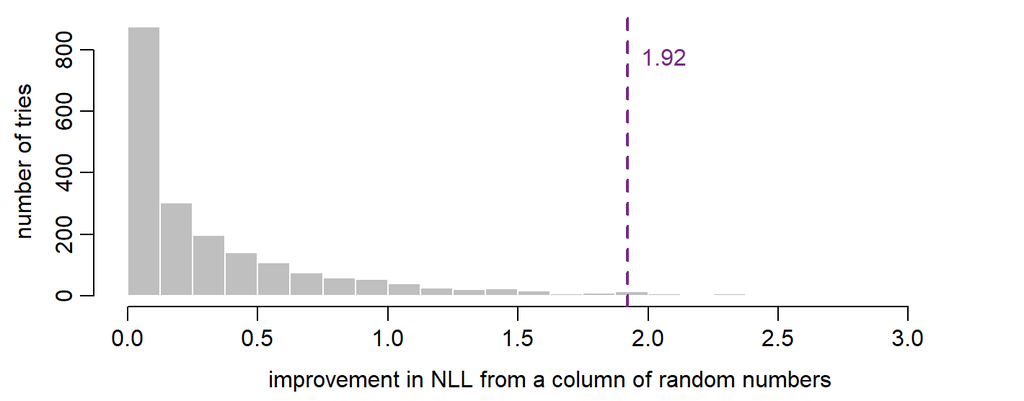

**Every one** improved the fit. A median of 0.17, and 2% by more than 1.92.

## Try it: a nonsense predictor

```r
junk <- runif(nrow(occ))      # 23 random numbers: related to nothing

occ_junk <- function(params, n_occupied, n_routes, elapsed, junk){
  p <- plogis(params[1] + params[2] * elapsed + params[3] * junk)
  -sum(dbinom(n_occupied, size = n_routes, prob = p, log = TRUE))
}
parnames(occ_junk) <- c("a", "b", "c")

m_junk <- mle2(minuslogl = occ_junk,
               start = c(a = 2, b = -0.05, c = 0),
               data = c(occ_data, list(junk = junk)))

m_occ@min - m_junk@min        # how much did nonsense "improve" the fit?
```

**Compare with your neighbor.** Everyone has different random numbers.

# The likelihood ratio test

## Nested models

Start with the biggest model. Each one below it is **nested** in it:

| Model | Equation | Fix in the biggest | Number fixed |
| --- | --- | --- | --- |
| Biggest | $Y = m_1 X_1 + m_2 X_2 + b$ |  |  |
| Smaller | $Y = m_1 X_1 + b$ | $m_2 = 0$ | 1 |
| Smallest | $Y = b$ | $m_1 = m_2 = 0$ | 2 |
| Equal slopes | $Y = m (X_1 + X_2) + b$ | $m_1 = m_2$ | 1 |

**Not nested:** $Y = m_1 X_1 + b$ against $Y = m_2 X_2 + b$, or $Y = m X + b$ against $Y = b\,e^{mX}$

Nested: you get the smaller model by setting the bigger one’s parameters to zero, or equal to each other. Keep count of how many you fix: the test on the next slide needs it.

## The test

Same as Tuesday, pointed at two models:

$$\text{deviance} = 2 \times \big(\text{NLL}_{\text{smaller}} - \text{NLL}_{\text{bigger}}\big)$$

If the smaller model is true, the deviance follows a **chi-squared** distribution. Its one setting, the **degrees of freedom**, is here simply **the number of parameters you fixed**: the last column of the previous slide.

| Extra parameters | The bigger model must improve the NLL by more than |
| --- | --- |
| 1 | **1.92** |
| 2 | 3.00 |
| 3 | 3.91 |

If the extra parameters were useless, an improvement this big would be rare. So when we see one, we keep them.

## By hand, then with `anova()`

```r
const_nll <- function(params, n_occupied, n_routes){
  p <- plogis(params[1])                      # no year: one p for every year
  -sum(dbinom(n_occupied, size = n_routes, prob = p, log = TRUE))
}
parnames(const_nll) <- "a"
m_const <- mle2(minuslogl = const_nll, start = c(a = 1),
                data = list(n_occupied = occ$n_occupied, n_routes = occ$n_routes))

deviance_occ <- 2 * (m_const@min - m_occ@min)
deviance_occ
pchisq(deviance_occ, df = 1, lower.tail = FALSE)   # the p-value

anova(m_const, m_occ)                              # the same test, in one line
```

**Check:** a deviance of 46.4. R prints the p-value as `9.439462e-12`, which means 0.0000000000094: the e-12 moves the decimal point 12 places left.

## Reading `anova()`

```
Likelihood Ratio Tests
Model 1: m_const, [const_nll]: a
Model 2: m_occ, [occ_nll2]: a+b
  Tot Df Deviance  Chisq Df Pr(>Chisq)
1      1   159.82
2      2   113.38 46.441  1  9.439e-12 ***
---
Signif. codes:  0 '***' 0.001 '**' 0.01 '*' 0.05 '.' 0.1 ' ' 1
```

- `Deviance` is $2 \times$ NLL for each model
- `Chisq` is the **difference**: the test statistic
- `Df` is how many parameters were fixed to get the smaller model
- `Pr(>Chisq)` is the p-value

A small p-value means the bigger model gained more than chance would give it. Keep the bigger model.

## So which model wins?

|  | NLL | Parameters |
| --- | --- | --- |
| one $p$ for every year | 79.9 | 1 |
| $p$ changes with year | 56.7 | 2 |

- The year model improves the NLL by **23.2**. Chance alone would rarely give more than **1.92**
- The p-value is far below 0.05: about **9 in a trillion**

**The year model wins.** Bobwhite occupancy really is declining; a flat line does not fit the data.

## Your turn: test the nonsense

Earlier you added a column of random numbers to the model. Test it the same way:

```r
anova(m_occ, m_junk)
```

**Is the p-value above or below 0.05? Which model do you keep?**

It should be **well above 0.05**: the random column did not gain more than chance would. **Keep the simpler model**, `m_occ`.

# AIC

## When models are not nested

Last Thursday: do bobwhite counts follow **year** or **development**? Same number of parameters, neither a special case of the other. **No likelihood ratio test.**

$$\text{AIC} = 2 \times \text{NLL} + 2 \times (\text{number of parameters})$$

- **Lower is better**, as with the NLL
- Each parameter costs **1 unit** of NLL. Compare: the test’s 1.92
- Only **differences** mean anything. An AIC of 9079 on its own says nothing

Works for **any** set of models fitted to **the same data**.

AIC is how badly a model fits, plus a charge for every parameter. The lowest total wins.

## A shortcut: the formula version

Every model so far was a function, then `mle2()`. For a one-line model there is a shortcut: **write the model as a formula**.

**Function**

```r
urban_nll2 <- function(params, y, u){
  mu <- params[1] * exp(params[2] * u)
  -sum(dnbinom(y, mu = mu,
               size = params[3],
               log = TRUE))
}
parnames(urban_nll2) <- c("mu0", "b", "k")
mle2(minuslogl = urban_nll2,
     start = c(mu0 = 12, b = -3, k = 1.4),
     data = list(y = counts$count,
                 u = counts$frac_built))
```

**Formula**

```r
mle2(count ~ dnbinom(
       mu = mu0 * exp(b * frac_built),
       size = k),
     start = list(mu0 = 12, b = -3,
                  k = 1.4),
     data = counts)
```

Read it as: *count is negative binomial, with this mean and this size.*

**Same model, same answer.** The formula version is what the assignment uses.

## Three models for the counts

```r
m_flat <- mle2(count ~ dnbinom(mu = mu0, size = k),
               start = list(mu0 = 10, k = 1.4), data = counts)

m_year <- mle2(count ~ dnbinom(mu = mu0 * exp(r * elapsed), size = k),
               start = list(mu0 = 15, r = -0.03, k = 1.4), data = counts)

m_urban <- mle2(count ~ dnbinom(mu = mu0 * exp(b * frac_built), size = k),
                start = list(mu0 = 12, b = -3, k = 1.4), data = counts)

AIC(m_flat)
2 * m_flat@min + 2 * 2     # the same number, by hand
```

$$\text{AIC} = 2 \times \text{NLL} + 2 \times (\text{number of parameters})$$

By hand: `m_flat@min` is the NLL, and `m_flat` has **2** parameters, `mu0` and `k`. **Check:** both lines give 9257.5.

## Your turn: year **and** development

Does a model with **both** do better than either alone?

```r
m_both <- mle2(count ~ dnbinom(mu = mu0 * exp(b * frac_built + r * elapsed),
                               size = k),
               start = list(mu0 = 15, b = -3, r = -0.03, k = 1.4),
               data = counts)

# compare all four with AICtab(). Give it the four fitted models, and
# base = TRUE so it shows the AIC itself and not only the differences
```

Which is best? **Is year versus development a question the likelihood ratio test could have answered?**

## Reading `AICtab()`

| model | AIC | dAIC | parameters | weight |
| --- | --- | --- | --- | --- |
| m_both | 9079.4 | 0.0 | 4 | 1.000 |
| m_urban | 9154.3 | 74.9 | 3 | <0.001 |
| m_year | 9197.2 | 117.8 | 3 | <0.001 |
| m_flat | 9257.5 | 178.1 | 2 | <0.001 |

- `dAIC`: how far behind the best model. **0 is the best**
- Rough guide: under **2**, about as good; over **10**, essentially no support
- `weight`: the share of support among **these** models

**Both matter**, and development more than year. Neither replaces the other: development explains **where** bobwhite are scarce, year **how fast** they are going.

## What AIC cannot see

Lecture 16’s two occupancy curves, both with two parameters:

| model | AIC | dAIC | parameters | weight |
| --- | --- | --- | --- | --- |
| m_lin | 115.1 | 0.0 | 2 | 0.754 |
| m_occ | 117.4 | 2.2 | 2 | 0.246 |

`m_lin` is the guarded straight line. AIC prefers it.

It also predicts an occupancy **below zero** by 2100.

**AIC ranks only the models you give it, and only on fit.** Whether a model is biologically possible is your job.

# Do two species differ?

## Two birds, one gradient

**Northern Cardinal**: feeders, hedges, shrubby edges. **Northern Bobwhite**: grassland and open pine. Every Florida route surveyed in 2019:

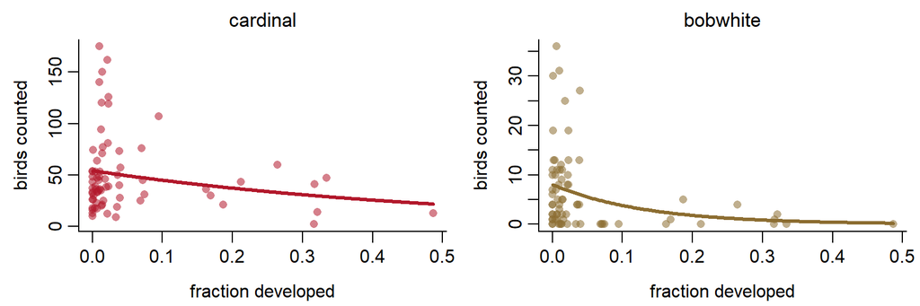

**Does development affect them differently?**

## Get set up, again

```r
birds <- bbs_two_species          # from the course data package

head(birds)
table(birds$species)

# make cardinal the first level, so it is the baseline in the models
birds$species <- factor(birds$species, levels = c("cardinal", "bobwhite"))
```

The development model from earlier, on the log scale to keep $\mu_0$ and $k$ positive:

$$\mu = \mu_0 \, e^{\,b \cdot \text{development}} \qquad \text{count} \sim \text{NegBin}(\mu, k)$$

**Three ways the species could differ:** in $\mu_0$ (birds where nothing is built), in $b$ (how fast counts fall with development), or in $k$ (how variable routes are).

## Letting a parameter differ: `parameters =`

```r
form <- count ~ dnbinom(mu = exp(log_mu0 + b * frac_built), size = exp(log_k))
start <- list(log_mu0 = 2, b = 0, log_k = 0)

m_same <- mle2(form, start = start, data = birds)    # one model for both species

m_mu <- mle2(form, start = start, data = birds,
             parameters = list(log_mu0 ~ species))   # a separate mu0 for each

coef(m_mu)
```

```
    log_mu0.(Intercept) log_mu0.speciesbobwhite                       b
                  4.092                  -2.142                  -3.564
                  log_k
                  0.230
```

`log_mu0.(Intercept)` is the **cardinal** value. `log_mu0.speciesbobwhite` is **how much bobwhite differ** from it.

## Your turn: the other ways to differ

```r
m_b <- mle2(form, start = start, data = birds,
            parameters = list(b ~ species))

# now fit three more, changing only the parameters line:
#   m_mub   log_mu0 and b both differ
#   m_muk   log_mu0 and log_k differ
#   m_all   all three differ

# then compare all six with AICtab(), base = TRUE
```

**Which way do the species differ?**

## Ranking the six models

| model | AIC | dAIC | parameters | weight |
| --- | --- | --- | --- | --- |
| m_all | 1079.6 | 0.0 | 6 | 0.901 |
| m_muk | 1084.0 | 4.4 | 5 | 0.099 |
| m_mub | 1098.7 | 19.1 | 5 | <0.001 |
| m_mu | 1105.2 | 25.6 | 4 | <0.001 |
| m_b | 1174.5 | 94.9 | 4 | <0.001 |
| m_same | 1208.6 | 129.0 | 3 | <0.001 |

**`m_all`: all three differ**, with 90% of the weight.

## How they differ

| From `m_all` | cardinal | bobwhite |
| --- | --- | --- |
| birds where nothing is built | 54 | 8 |
| development that halves the count | 37% | 9% |
| $k$: smaller means more variable | 2.33 | 0.67 |

- Bobwhite lose birds to development **four times as fast**
- Bobwhite are far **patchier**: plentiful on some routes, absent from 19 of 71

Groups can differ in more than their average. Here the two species also differ in how fast development hurts them, and in how evenly they are spread.

## The test asks a narrower question

```
Likelihood Ratio Tests
Model 1: m_same, count~dnbinom(mu=exp(log_mu0+b*frac_built),size=exp(log_k)):
Model 2: m_mu, count~dnbinom(mu=exp(log_mu0+b*frac_built),size=exp(log_k)):
          log_mu0~species
Model 3: m_mub, count~dnbinom(mu=exp(log_mu0+b*frac_built),size=exp(log_k)):
          log_mu0~species, b~species
  Tot Df Deviance    Chisq Df Pr(>Chisq)
1      3   1202.6
2      4   1097.2 105.4223  1  < 2.2e-16 ***
3      5   1088.7   8.5027  1   0.003546 **
---
Signif. codes:  0 '***' 0.001 '**' 0.01 '*' 0.05 '.' 0.1 ' ' 1
```

Adding a separate $\mu_0$: a huge gain. Adding $b$ **after** it: $p$ = 0.004.

A sequence of tests checks **one path** through the models, in the order you list them. AIC compares **all of them at once**, and found the difference in $k$, which this path never tried.

A test compares two models at a time. AIC lines up all of them at once.

## Rules for a fair comparison

| Rule | Why |
| --- | --- |
| **Same rows** in every model | NLL adds up over rows; drop one and the NLL changes for reasons unrelated to the model. Run `na.omit()` on the data **once**, before fitting anything |
| **Same response**, on the same scale | `count` and `log(count)` have likelihoods on different scales. Never compare them by AIC |
| **Count every parameter**, including `k` and `sd` | AIC does it for you with `mle2`. By hand, people forget them |
| **Every model has to make sense** | AIC ranks only what you give it |

## Comparing distributions

The bobwhite development model from earlier, with three different distributions:

| distribution | parameters | AIC |
| --- | --- | --- |
| negative binomial | 3 | 9154.3 |
| Poisson | 2 | 16180.6 |
| normal | 3 | 10215.1 |

- The negative binomial wins by about **7,000** units
- Both count models find the **same curve**: $b$ = -3.2 and -3.3. The distribution changes the fit, not the curve

The normal looks better than the Poisson. **That comparison is not allowed.** Next slide.

## Rules for comparing distributions

- **Discrete with discrete, continuous with continuous.** A count model gives the **probability** of each count; a normal gives a **density**. Their AICs are in different units, so the normal row on the last slide cannot be compared
- **Same response, same scale.** For a measurement, try `dlnorm(y)` against `dgamma(y)`, never `dnorm(log(y))` against `dgamma(y)`
- **Count the distribution’s own parameter**: $k$ for the negative binomial, the standard deviation for the normal
- **Poisson against negative binomial: use AIC**, not the likelihood ratio test

You can let AIC choose the distribution, as long as every candidate describes the same numbers in the same way: all counts, or all measurements.

## Assignment 3, Part 1: a strategy

1. **Run the starter model** as given. Note its AIC.
2. **Remove one piece at a time**: a covariate, an exponent, a group effect. Fit each as its own model.
3. **`AICtab()`** them all together.
4. **Keep removing** from the best one until nothing improves.
5. **Write it down**: which model, and why, in a sentence of biology.

**Check the distribution before the terms.** If the data are far more variable than the distribution allows, removing terms will not fix it.

## Which tool, when

| You want to know | Use | In plain words |
| --- | --- | --- |
| Could this parameter be zero? | its **confidence interval**, `confint()` | is zero among the values the data cannot rule out? |
| Is the bigger of two **nested** models better? | **likelihood ratio test**, `anova()` | did the extra parameters gain more than chance would? |
| Which of **several** models is best? | **AIC**, `AICtab()` | lowest fit-plus-charge wins; within 2 is a tie |
| Does the model make biological sense? | **you** | no statistic checks this |

## Additional practice

Is development **worse for bobwhite in later years**? Let the effect of development change with year:

```r
# 1. add a term i * frac_built * elapsed inside exp(), next to the other two,
#    and an i = 0 in start. Call the model m_int
# 2. is m_both nested in m_int? Then compare them with anova()
# 3. and with AICtab(). Do the test and AIC agree?
# 4. which would you report, and why?
```

## Before next class

Read Bolker **7.1 - 7.2**

If the course data package did not finish installing in class, run it at home:

```r
options(timeout = 600)
remotes::install_github("bmaitner/biometry_course", subdir = "biometrydata", upgrade = "never")
```